# Risk Factor Analysis

## Outcome Variable

**Outcome Variable:** y_rate_len

## Predictor Variables

**Intervention Variable:** impfloor

**Adjustment Set:**

unadjusted

## Stratifying Variables

The analysis was stratified on these variable(s):

- agecat
- studyid
- country

## Data Summary

| agecat | studyid | country | impfloor | n_cell | n |
| --- | --- | --- | --- | --- | --- |
| 0-3 months | ki0047075b-MAL-ED | BANGLADESH | 0 | 19 | 237 |
| 0-3 months | ki0047075b-MAL-ED | BANGLADESH | 1 | 218 | 237 |
| 0-3 months | ki1017093-NIH-Birth | BANGLADESH | 0 | 63 | 564 |
| 0-3 months | ki1017093-NIH-Birth | BANGLADESH | 1 | 501 | 564 |
| 0-3 months | ki1017093b-PROVIDE | BANGLADESH | 0 | 53 | 634 |
| 0-3 months | ki1017093b-PROVIDE | BANGLADESH | 1 | 581 | 634 |
| 0-3 months | ki1017093c-NIH-Crypto | BANGLADESH | 0 | 174 | 720 |
| 0-3 months | ki1017093c-NIH-Crypto | BANGLADESH | 1 | 546 | 720 |
| 0-3 months | kiGH5241-JiVitA-3 | BANGLADESH | 0 | 18670 | 20001 |
| 0-3 months | kiGH5241-JiVitA-3 | BANGLADESH | 1 | 1331 | 20001 |
| 0-3 months | kiGH5241-JiVitA-4 | BANGLADESH | 0 | 1623 | 1805 |
| 0-3 months | kiGH5241-JiVitA-4 | BANGLADESH | 1 | 182 | 1805 |
| 0-3 months | ki0047075b-MAL-ED | BRAZIL | 0 | 2 | 174 |
| 0-3 months | ki0047075b-MAL-ED | BRAZIL | 1 | 172 | 174 |
| 0-3 months | ki0047075b-MAL-ED | INDIA | 0 | 11 | 194 |
| 0-3 months | ki0047075b-MAL-ED | INDIA | 1 | 183 | 194 |
| 0-3 months | ki1000108-CMC-V-BCS-2002 | INDIA | 1 | 67 | 67 |
| 0-3 months | ki1000108-IRC | INDIA | 1 | 280 | 280 |
| 0-3 months | ki0047075b-MAL-ED | NEPAL | 0 | 100 | 168 |
| 0-3 months | ki0047075b-MAL-ED | NEPAL | 1 | 68 | 168 |
| 0-3 months | ki0047075b-MAL-ED | PERU | 0 | 204 | 260 |
| 0-3 months | ki0047075b-MAL-ED | PERU | 1 | 56 | 260 |
| 0-3 months | ki1114097-CONTENT | PERU | 0 | 2 | 29 |
| 0-3 months | ki1114097-CONTENT | PERU | 1 | 27 | 29 |
| 0-3 months | ki0047075b-MAL-ED | SOUTH AFRICA | 0 | 20 | 215 |
| 0-3 months | ki0047075b-MAL-ED | SOUTH AFRICA | 1 | 195 | 215 |
| 0-3 months | ki0047075b-MAL-ED | TANZANIA, UNITED REPUBLIC OF | 0 | 213 | 224 |
| 0-3 months | ki0047075b-MAL-ED | TANZANIA, UNITED REPUBLIC OF | 1 | 11 | 224 |
| 3-6 months | ki0047075b-MAL-ED | BANGLADESH | 0 | 17 | 231 |
| 3-6 months | ki0047075b-MAL-ED | BANGLADESH | 1 | 214 | 231 |

[output cut: 88 more lines]

The following strata were considered:

- agecat: 0-3 months, studyid: ki0047075b-MAL-ED, country: BANGLADESH
- agecat: 0-3 months, studyid: ki0047075b-MAL-ED, country: BRAZIL
- agecat: 0-3 months, studyid: ki0047075b-MAL-ED, country: INDIA
- agecat: 0-3 months, studyid: ki0047075b-MAL-ED, country: NEPAL
- agecat: 0-3 months, studyid: ki0047075b-MAL-ED, country: PERU
- agecat: 0-3 months, studyid: ki0047075b-MAL-ED, country: SOUTH AFRICA
- agecat: 0-3 months, studyid: ki0047075b-MAL-ED, country: TANZANIA, UNITED REPUBLIC OF
- agecat: 0-3 months, studyid: ki1000108-CMC-V-BCS-2002, country: INDIA
- agecat: 0-3 months, studyid: ki1000108-IRC, country: INDIA
- agecat: 0-3 months, studyid: ki1017093-NIH-Birth, country: BANGLADESH
- agecat: 0-3 months, studyid: ki1017093b-PROVIDE, country: BANGLADESH
- agecat: 0-3 months, studyid: ki1017093c-NIH-Crypto, country: BANGLADESH
- agecat: 0-3 months, studyid: ki1114097-CONTENT, country: PERU
- agecat: 0-3 months, studyid: kiGH5241-JiVitA-3, country: BANGLADESH
- agecat: 0-3 months, studyid: kiGH5241-JiVitA-4, country: BANGLADESH
- agecat: 12-24 months, studyid: ki0047075b-MAL-ED, country: BANGLADESH
- agecat: 12-24 months, studyid: ki0047075b-MAL-ED, country: BRAZIL
- agecat: 12-24 months, studyid: ki0047075b-MAL-ED, country: INDIA
- agecat: 12-24 months, studyid: ki0047075b-MAL-ED, country: NEPAL
- agecat: 12-24 months, studyid: ki0047075b-MAL-ED, country: PERU
- agecat: 12-24 months, studyid: ki0047075b-MAL-ED, country: SOUTH AFRICA
- agecat: 12-24 months, studyid: ki0047075b-MAL-ED, country: TANZANIA, UNITED REPUBLIC OF
- agecat: 12-24 months, studyid: ki1000108-CMC-V-BCS-2002, country: INDIA
- agecat: 12-24 months, studyid: ki1000108-IRC, country: INDIA
- agecat: 12-24 months, studyid: ki1017093-NIH-Birth, country: BANGLADESH
- agecat: 12-24 months, studyid: ki1017093b-PROVIDE, country: BANGLADESH
- agecat: 12-24 months, studyid: ki1017093c-NIH-Crypto, country: BANGLADESH
- agecat: 12-24 months, studyid: ki1113344-GMS-Nepal, country: NEPAL
- agecat: 12-24 months, studyid: ki1114097-CONTENT, country: PERU
- agecat: 12-24 months, studyid: kiGH5241-JiVitA-3, country: BANGLADESH
- agecat: 12-24 months, studyid: kiGH5241-JiVitA-4, country: BANGLADESH
- agecat: 3-6 months, studyid: ki0047075b-MAL-ED, country: BANGLADESH
- agecat: 3-6 months, studyid: ki0047075b-MAL-ED, country: BRAZIL
- agecat: 3-6 months, studyid: ki0047075b-MAL-ED, country: INDIA
- agecat: 3-6 months, studyid: ki0047075b-MAL-ED, country: NEPAL
- agecat: 3-6 months, studyid: ki0047075b-MAL-ED, country: PERU
- agecat: 3-6 months, studyid: ki0047075b-MAL-ED, country: SOUTH AFRICA
- agecat: 3-6 months, studyid: ki0047075b-MAL-ED, country: TANZANIA, UNITED REPUBLIC OF
- agecat: 3-6 months, studyid: ki1000108-CMC-V-BCS-2002, country: INDIA
- agecat: 3-6 months, studyid: ki1000108-IRC, country: INDIA
- agecat: 3-6 months, studyid: ki1017093-NIH-Birth, country: BANGLADESH
- agecat: 3-6 months, studyid: ki1017093b-PROVIDE, country: BANGLADESH
- agecat: 3-6 months, studyid: ki1017093c-NIH-Crypto, country: BANGLADESH
- agecat: 3-6 months, studyid: ki1113344-GMS-Nepal, country: NEPAL
- agecat: 3-6 months, studyid: ki1114097-CONTENT, country: PERU
- agecat: 3-6 months, studyid: kiGH5241-JiVitA-3, country: BANGLADESH
- agecat: 3-6 months, studyid: kiGH5241-JiVitA-4, country: BANGLADESH
- agecat: 6-12 months, studyid: ki0047075b-MAL-ED, country: BANGLADESH
- agecat: 6-12 months, studyid: ki0047075b-MAL-ED, country: BRAZIL
- agecat: 6-12 months, studyid: ki0047075b-MAL-ED, country: INDIA
- agecat: 6-12 months, studyid: ki0047075b-MAL-ED, country: NEPAL
- agecat: 6-12 months, studyid: ki0047075b-MAL-ED, country: PERU
- agecat: 6-12 months, studyid: ki0047075b-MAL-ED, country: SOUTH AFRICA
- agecat: 6-12 months, studyid: ki0047075b-MAL-ED, country: TANZANIA, UNITED REPUBLIC OF
- agecat: 6-12 months, studyid: ki1000108-CMC-V-BCS-2002, country: INDIA
- agecat: 6-12 months, studyid: ki1000108-IRC, country: INDIA
- agecat: 6-12 months, studyid: ki1017093-NIH-Birth, country: BANGLADESH
- agecat: 6-12 months, studyid: ki1017093b-PROVIDE, country: BANGLADESH
- agecat: 6-12 months, studyid: ki1017093c-NIH-Crypto, country: BANGLADESH
- agecat: 6-12 months, studyid: ki1113344-GMS-Nepal, country: NEPAL
- agecat: 6-12 months, studyid: ki1114097-CONTENT, country: PERU
- agecat: 6-12 months, studyid: kiGH5241-JiVitA-3, country: BANGLADESH
- agecat: 6-12 months, studyid: kiGH5241-JiVitA-4, country: BANGLADESH

### Dropped Strata

Some strata were dropped due to rare outcomes:

- agecat: 0-3 months, studyid: ki0047075b-MAL-ED, country: BRAZIL
- agecat: 0-3 months, studyid: ki1114097-CONTENT, country: PERU
- agecat: 3-6 months, studyid: ki0047075b-MAL-ED, country: BRAZIL
- agecat: 6-12 months, studyid: ki0047075b-MAL-ED, country: BRAZIL
- agecat: 12-24 months, studyid: ki0047075b-MAL-ED, country: BRAZIL

## Methods Detail

We’re interested in the causal parameters $E[Y_a]$ for all values of $a \in \mathcal{A}$. These parameters represent the mean outcome if, possibly contrary to fact, we intervened to set all units to have $A=a$. Under the randomization and positivity assumptions, these are identified by the statistical parameters $\psi_a=E_W[E_{Y|A,W}(Y|A=a,W)]$. In addition, we’re interested in the mean of $Y$, $E[Y]$ under no intervention (the observed mean). We will estimate these parameters by using SuperLearner to fit the relevant likelihood factors – $E_{Y|A,W}(Y|A=a,W)$ and $p(A=a|W)$, and then updating our likelihood fit using a joint TMLE.

For unadjusted analyses ($W=\{\}$), initial likelihoods were estimated using Lrnr_glm to estimate the simple $E(Y|A)$ and Lrnr_mean to estimate $p(A)$. For adjusted analyses, a small library containing Lrnr_glmnet, Lrnr_xgboost, and Lrnr_mean was used.

Having estimated these parameters, we will then use the delta method to estimate relative risks and attributable risks relative to a prespecified baseline level of $A$.

[output not shown]

[output cut: 2009 more lines]

[output not shown]

# Results Detail

## Results Plots

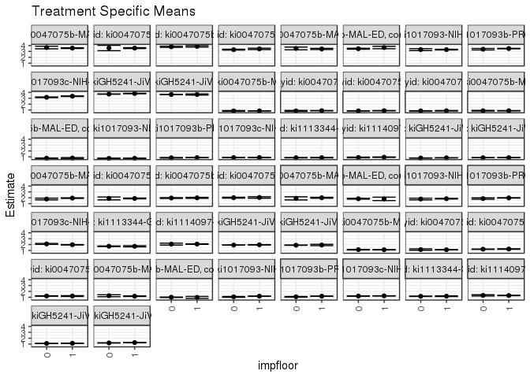

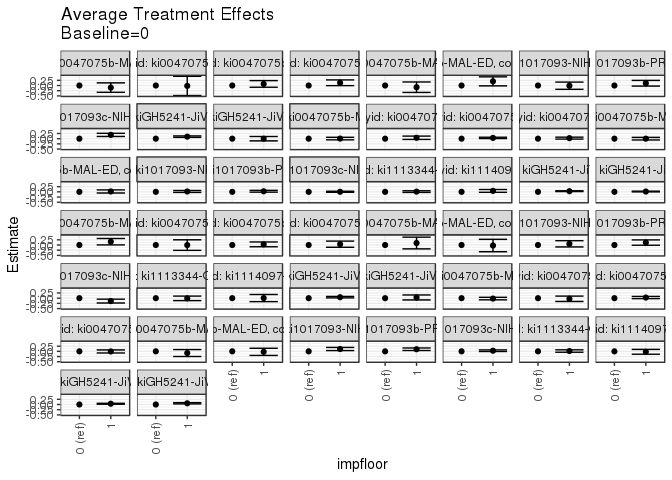

## Results Table

### Parameter: TSM

| agecat | studyid | country | intervention_level | baseline_level | estimate | ci_lower | ci_upper |
| --- | --- | --- | --- | --- | --- | --- | --- |
| 0-3 months | ki0047075b-MAL-ED | BANGLADESH | 0 | NA | 3.6634136 | 3.4453388 | 3.8814885 |
| 0-3 months | ki0047075b-MAL-ED | BANGLADESH | 1 | NA | 3.5635748 | 3.4978191 | 3.6293304 |
| 0-3 months | ki0047075b-MAL-ED | INDIA | 0 | NA | 3.5860027 | 3.1288111 | 4.0431943 |
| 0-3 months | ki0047075b-MAL-ED | INDIA | 1 | NA | 3.5677680 | 3.4908125 | 3.6447234 |
| 0-3 months | ki0047075b-MAL-ED | NEPAL | 0 | NA | 3.7934080 | 3.6954219 | 3.8913940 |
| 0-3 months | ki0047075b-MAL-ED | NEPAL | 1 | NA | 3.8704389 | 3.7445319 | 3.9963460 |
| 0-3 months | ki0047075b-MAL-ED | PERU | 0 | NA | 3.3059532 | 3.2337997 | 3.3781068 |
| 0-3 months | ki0047075b-MAL-ED | PERU | 1 | NA | 3.4386741 | 3.3199695 | 3.5573787 |
| 0-3 months | ki0047075b-MAL-ED | SOUTH AFRICA | 0 | NA | 3.5105399 | 3.2787499 | 3.7423298 |
| 0-3 months | ki0047075b-MAL-ED | SOUTH AFRICA | 1 | NA | 3.4291076 | 3.3293126 | 3.5289027 |
| 0-3 months | ki0047075b-MAL-ED | TANZANIA, UNITED REPUBLIC OF | 0 | NA | 3.4621238 | 3.3810245 | 3.5432231 |
| 0-3 months | ki0047075b-MAL-ED | TANZANIA, UNITED REPUBLIC OF | 1 | NA | 3.6628519 | 3.4606895 | 3.8650143 |
| 0-3 months | ki1017093-NIH-Birth | BANGLADESH | 0 | NA | 3.3207366 | 3.1580801 | 3.4833931 |
| 0-3 months | ki1017093-NIH-Birth | BANGLADESH | 1 | NA | 3.3120552 | 3.2536366 | 3.3704739 |
| 0-3 months | ki1017093b-PROVIDE | BANGLADESH | 0 | NA | 3.3820778 | 3.2520434 | 3.5121122 |
| 0-3 months | ki1017093b-PROVIDE | BANGLADESH | 1 | NA | 3.4918469 | 3.4508488 | 3.5328449 |
| 0-3 months | ki1017093c-NIH-Crypto | BANGLADESH | 0 | NA | 3.1641309 | 3.1033793 | 3.2248824 |
| 0-3 months | ki1017093c-NIH-Crypto | BANGLADESH | 1 | NA | 3.3470778 | 3.3011983 | 3.3929572 |
| 0-3 months | kiGH5241-JiVitA-3 | BANGLADESH | 0 | NA | 3.7116642 | 3.7012219 | 3.7221065 |
| 0-3 months | kiGH5241-JiVitA-3 | BANGLADESH | 1 | NA | 3.8096327 | 3.7756507 | 3.8436147 |
| 0-3 months | kiGH5241-JiVitA-4 | BANGLADESH | 0 | NA | 3.6386604 | 3.6057642 | 3.6715565 |
| 0-3 months | kiGH5241-JiVitA-4 | BANGLADESH | 1 | NA | 3.6382375 | 3.5394033 | 3.7370716 |
| 3-6 months | ki0047075b-MAL-ED | BANGLADESH | 0 | NA | 1.7803988 | 1.6360157 | 1.9247819 |
| 3-6 months | ki0047075b-MAL-ED | BANGLADESH | 1 | NA | 1.9397752 | 1.8881416 | 1.9914087 |
| 3-6 months | ki0047075b-MAL-ED | INDIA | 0 | NA | 1.8871927 | 1.6401866 | 2.1341989 |
| 3-6 months | ki0047075b-MAL-ED | INDIA | 1 | NA | 1.8834834 | 1.8202272 | 1.9467397 |
| 3-6 months | ki0047075b-MAL-ED | NEPAL | 0 | NA | 1.9554460 | 1.8788765 | 2.0320154 |
| 3-6 months | ki0047075b-MAL-ED | NEPAL | 1 | NA | 1.9869896 | 1.9005273 | 2.0734518 |
| 3-6 months | ki0047075b-MAL-ED | PERU | 0 | NA | 2.0097542 | 1.9335965 | 2.0859119 |
| 3-6 months | ki0047075b-MAL-ED | PERU | 1 | NA | 2.0491923 | 1.9220383 | 2.1763463 |

[output cut: 70 more lines]

### Parameter: E(Y)

| agecat | studyid | country | intervention_level | baseline_level | estimate | ci_lower | ci_upper |
| --- | --- | --- | --- | --- | --- | --- | --- |
| 0-3 months | ki0047075b-MAL-ED | BANGLADESH | NA | NA | 3.5715787 | 3.5085237 | 3.6346338 |
| 0-3 months | ki0047075b-MAL-ED | INDIA | NA | NA | 3.5688019 | 3.4917177 | 3.6458861 |
| 0-3 months | ki0047075b-MAL-ED | NEPAL | NA | NA | 3.8245872 | 3.7469221 | 3.9022522 |
| 0-3 months | ki0047075b-MAL-ED | PERU | NA | NA | 3.3345392 | 3.2720665 | 3.3970119 |
| 0-3 months | ki0047075b-MAL-ED | SOUTH AFRICA | NA | NA | 3.4366827 | 3.3435842 | 3.5297813 |
| 0-3 months | ki0047075b-MAL-ED | TANZANIA, UNITED REPUBLIC OF | NA | NA | 3.4719810 | 3.3940197 | 3.5499422 |
| 0-3 months | ki1017093-NIH-Birth | BANGLADESH | NA | NA | 3.3130250 | 3.2580425 | 3.3680074 |
| 0-3 months | ki1017093b-PROVIDE | BANGLADESH | NA | NA | 3.4826706 | 3.4434873 | 3.5218539 |
| 0-3 months | ki1017093c-NIH-Crypto | BANGLADESH | NA | NA | 3.3028656 | 3.2646714 | 3.3410598 |
| 0-3 months | kiGH5241-JiVitA-3 | BANGLADESH | NA | NA | 3.7181837 | 3.7078402 | 3.7285271 |
| 0-3 months | kiGH5241-JiVitA-4 | BANGLADESH | NA | NA | 3.6386177 | 3.6075243 | 3.6697112 |
| 3-6 months | ki0047075b-MAL-ED | BANGLADESH | NA | NA | 1.9280462 | 1.8787523 | 1.9773401 |
| 3-6 months | ki0047075b-MAL-ED | INDIA | NA | NA | 1.8837264 | 1.8224393 | 1.9450135 |
| 3-6 months | ki0047075b-MAL-ED | NEPAL | NA | NA | 1.9694808 | 1.9121182 | 2.0268433 |
| 3-6 months | ki0047075b-MAL-ED | PERU | NA | NA | 2.0183213 | 1.9525900 | 2.0840526 |
| 3-6 months | ki0047075b-MAL-ED | SOUTH AFRICA | NA | NA | 1.9877371 | 1.9066803 | 2.0687939 |
| 3-6 months | ki0047075b-MAL-ED | TANZANIA, UNITED REPUBLIC OF | NA | NA | 1.8323273 | 1.7640304 | 1.9006242 |
| 3-6 months | ki1017093-NIH-Birth | BANGLADESH | NA | NA | 1.8344466 | 1.7863211 | 1.8825720 |
| 3-6 months | ki1017093b-PROVIDE | BANGLADESH | NA | NA | 1.9654454 | 1.9303798 | 2.0005110 |
| 3-6 months | ki1017093c-NIH-Crypto | BANGLADESH | NA | NA | 2.0057973 | 1.9693775 | 2.0422170 |
| 3-6 months | ki1113344-GMS-Nepal | NEPAL | NA | NA | 1.7085479 | 1.6644702 | 1.7526256 |
| 3-6 months | ki1114097-CONTENT | PERU | NA | NA | 2.0841841 | 2.0362519 | 2.1321163 |
| 3-6 months | kiGH5241-JiVitA-3 | BANGLADESH | NA | NA | 1.9201192 | 1.9096572 | 1.9305812 |
| 3-6 months | kiGH5241-JiVitA-4 | BANGLADESH | NA | NA | 1.8987567 | 1.8688242 | 1.9286892 |
| 6-12 months | ki0047075b-MAL-ED | BANGLADESH | NA | NA | 1.1143928 | 1.0896103 | 1.1391753 |
| 6-12 months | ki0047075b-MAL-ED | INDIA | NA | NA | 1.1210558 | 1.0926349 | 1.1494766 |
| 6-12 months | ki0047075b-MAL-ED | NEPAL | NA | NA | 1.2246950 | 1.1984367 | 1.2509532 |
| 6-12 months | ki0047075b-MAL-ED | PERU | NA | NA | 1.2102315 | 1.1775158 | 1.2429472 |
| 6-12 months | ki0047075b-MAL-ED | SOUTH AFRICA | NA | NA | 1.1895267 | 1.1483723 | 1.2306812 |
| 6-12 months | ki0047075b-MAL-ED | TANZANIA, UNITED REPUBLIC OF | NA | NA | 1.0017429 | 0.9644127 | 1.0390732 |
| 6-12 months | ki1017093-NIH-Birth | BANGLADESH | NA | NA | 1.1689727 | 1.1465777 | 1.1913678 |
| 6-12 months | ki1017093b-PROVIDE | BANGLADESH | NA | NA | 1.1731762 | 1.1558671 | 1.1904853 |
| 6-12 months | ki1017093c-NIH-Crypto | BANGLADESH | NA | NA | 1.2281313 | 1.2106849 | 1.2455776 |
| 6-12 months | ki1113344-GMS-Nepal | NEPAL | NA | NA | 1.1695341 | 1.1470637 | 1.1920045 |
| 6-12 months | ki1114097-CONTENT | PERU | NA | NA | 1.3010517 | 1.2719491 | 1.3301542 |
| 6-12 months | kiGH5241-JiVitA-3 | BANGLADESH | NA | NA | 1.1071638 | 1.1004298 | 1.1138978 |
| 6-12 months | kiGH5241-JiVitA-4 | BANGLADESH | NA | NA | 1.2031930 | 1.1927974 | 1.2135886 |
| 12-24 months | ki0047075b-MAL-ED | BANGLADESH | NA | NA | 0.8459764 | 0.8299714 | 0.8619814 |
| 12-24 months | ki0047075b-MAL-ED | INDIA | NA | NA | 0.8803730 | 0.8630530 | 0.8976931 |
| 12-24 months | ki0047075b-MAL-ED | NEPAL | NA | NA | 0.8618683 | 0.8460858 | 0.8776508 |
| 12-24 months | ki0047075b-MAL-ED | PERU | NA | NA | 0.8463453 | 0.8256453 | 0.8670453 |
| 12-24 months | ki0047075b-MAL-ED | SOUTH AFRICA | NA | NA | 0.8699064 | 0.8475321 | 0.8922808 |
| 12-24 months | ki0047075b-MAL-ED | TANZANIA, UNITED REPUBLIC OF | NA | NA | 0.7673730 | 0.7437452 | 0.7910008 |
| 12-24 months | ki1017093-NIH-Birth | BANGLADESH | NA | NA | 0.7493363 | 0.7349635 | 0.7637092 |
| 12-24 months | ki1017093b-PROVIDE | BANGLADESH | NA | NA | 0.8575519 | 0.8455586 | 0.8695452 |
| 12-24 months | ki1017093c-NIH-Crypto | BANGLADESH | NA | NA | 0.8755729 | 0.8637860 | 0.8873598 |
| 12-24 months | ki1113344-GMS-Nepal | NEPAL | NA | NA | 0.8456379 | 0.8278807 | 0.8633951 |
| 12-24 months | ki1114097-CONTENT | PERU | NA | NA | 0.9259464 | 0.8927736 | 0.9591191 |
| 12-24 months | kiGH5241-JiVitA-3 | BANGLADESH | NA | NA | 0.7965813 | 0.7912633 | 0.8018992 |
| 12-24 months | kiGH5241-JiVitA-4 | BANGLADESH | NA | NA | 0.8492084 | 0.8437753 | 0.8546415 |

### Parameter: ATE

| agecat | studyid | country | intervention_level | baseline_level | estimate | ci_lower | ci_upper |
| --- | --- | --- | --- | --- | --- | --- | --- |
| 0-3 months | ki0047075b-MAL-ED | BANGLADESH | 0 | 0 | 0.0000000 | 0.0000000 | 0.0000000 |
| 0-3 months | ki0047075b-MAL-ED | BANGLADESH | 1 | 0 | -0.0998388 | -0.3276116 | 0.1279340 |
| 0-3 months | ki0047075b-MAL-ED | INDIA | 0 | 0 | 0.0000000 | 0.0000000 | 0.0000000 |
| 0-3 months | ki0047075b-MAL-ED | INDIA | 1 | 0 | -0.0182347 | -0.4818577 | 0.4453883 |
| 0-3 months | ki0047075b-MAL-ED | NEPAL | 0 | 0 | 0.0000000 | 0.0000000 | 0.0000000 |
| 0-3 months | ki0047075b-MAL-ED | NEPAL | 1 | 0 | 0.0770309 | -0.0825117 | 0.2365736 |
| 0-3 months | ki0047075b-MAL-ED | PERU | 0 | 0 | 0.0000000 | 0.0000000 | 0.0000000 |
| 0-3 months | ki0047075b-MAL-ED | PERU | 1 | 0 | 0.1327208 | -0.0061925 | 0.2716342 |
| 0-3 months | ki0047075b-MAL-ED | SOUTH AFRICA | 0 | 0 | 0.0000000 | 0.0000000 | 0.0000000 |
| 0-3 months | ki0047075b-MAL-ED | SOUTH AFRICA | 1 | 0 | -0.0814322 | -0.3337924 | 0.1709279 |
| 0-3 months | ki0047075b-MAL-ED | TANZANIA, UNITED REPUBLIC OF | 0 | 0 | 0.0000000 | 0.0000000 | 0.0000000 |
| 0-3 months | ki0047075b-MAL-ED | TANZANIA, UNITED REPUBLIC OF | 1 | 0 | 0.2007281 | -0.0170947 | 0.4185508 |
| 0-3 months | ki1017093-NIH-Birth | BANGLADESH | 0 | 0 | 0.0000000 | 0.0000000 | 0.0000000 |
| 0-3 months | ki1017093-NIH-Birth | BANGLADESH | 1 | 0 | -0.0086814 | -0.1815104 | 0.1641477 |
| 0-3 months | ki1017093b-PROVIDE | BANGLADESH | 0 | 0 | 0.0000000 | 0.0000000 | 0.0000000 |
| 0-3 months | ki1017093b-PROVIDE | BANGLADESH | 1 | 0 | 0.1097691 | -0.0265753 | 0.2461134 |
| 0-3 months | ki1017093c-NIH-Crypto | BANGLADESH | 0 | 0 | 0.0000000 | 0.0000000 | 0.0000000 |
| 0-3 months | ki1017093c-NIH-Crypto | BANGLADESH | 1 | 0 | 0.1829469 | 0.1068176 | 0.2590762 |
| 0-3 months | kiGH5241-JiVitA-3 | BANGLADESH | 0 | 0 | 0.0000000 | 0.0000000 | 0.0000000 |
| 0-3 months | kiGH5241-JiVitA-3 | BANGLADESH | 1 | 0 | 0.0979686 | 0.0636480 | 0.1322891 |
| 0-3 months | kiGH5241-JiVitA-4 | BANGLADESH | 0 | 0 | 0.0000000 | 0.0000000 | 0.0000000 |
| 0-3 months | kiGH5241-JiVitA-4 | BANGLADESH | 1 | 0 | -0.0004229 | -0.1049810 | 0.1041352 |
| 3-6 months | ki0047075b-MAL-ED | BANGLADESH | 0 | 0 | 0.0000000 | 0.0000000 | 0.0000000 |
| 3-6 months | ki0047075b-MAL-ED | BANGLADESH | 1 | 0 | 0.1593764 | 0.0060385 | 0.3127142 |
| 3-6 months | ki0047075b-MAL-ED | INDIA | 0 | 0 | 0.0000000 | 0.0000000 | 0.0000000 |
| 3-6 months | ki0047075b-MAL-ED | INDIA | 1 | 0 | -0.0037093 | -0.2586865 | 0.2512680 |
| 3-6 months | ki0047075b-MAL-ED | NEPAL | 0 | 0 | 0.0000000 | 0.0000000 | 0.0000000 |
| 3-6 months | ki0047075b-MAL-ED | NEPAL | 1 | 0 | 0.0315436 | -0.0839493 | 0.1470365 |
| 3-6 months | ki0047075b-MAL-ED | PERU | 0 | 0 | 0.0000000 | 0.0000000 | 0.0000000 |
| 3-6 months | ki0047075b-MAL-ED | PERU | 1 | 0 | 0.0394382 | -0.1087784 | 0.1876547 |

[output cut: 70 more lines]